# Reuters poll data

## Overview

What this notebook does:

- load Reuters poll and GDP vintages
- descriptive statistics of forecast errors, RMSFE
- Mincer-Zarnowitz (MR) regressions to test forecast rationality
- load sentiment series
- compare sentiment with forecast errors visually
- augmented MR tests
- interpretation MR test results/forecast efficiency tests as in [Rambacussing and Kwiatkowski (2020, IJoF)](https://www.sciencedirect.com/science/article/abs/pii/S0169207020300595)
- encompassing test for selected sign-adjusted topics

Load required packages

```r
library(lubridate)
library(forcats)
library(ggplot2)
library(bundesbank)
library(ggsci)
library(dplyr)
library(tidyr)
```

directories, evaluation set-up

```r
# clear workspace
rm(list = ls())

# directories
dir_forecasts <- "/poll data/"
dir_sentiment <- "/sentiment/"

# filename
fname_sentiment <- "sentiment_lstm_quarter.csv"

# evaluation period
yys <- 2006:2018 # years
qqs <- 1:4 # quarters

# max and min horizons
max_h <- 3 # 3Q-ahead forecast (relative to the quarter in which the forecast is made)
min_h <- -1 # backcast
```

## Reuters poll data

function to read in and filter data

```r
get_forecasts <- function(yy, qq, dir_in, df_in, max_h, min_h)
{
  # define helper function
  dropNA_first <- function(df)
  # function that removes NA observations and drops first element
  # output is a vector
  {
    tmp <- df[!is.na(df)] # rem NA
    out <- tmp[-1] # drop first element
  }

  # read in csv
  dat <- read.csv(paste0(getwd(), dir_in, yy, "Q", qq, ".csv"))
  # get row indices
  ind_median <- grep("median", dat[, 1], ignore.case = TRUE)
  ind_min <- grep("min", dat[, 1], ignore.case = TRUE)
  ind_max <- grep("max", dat[, 1], ignore.case = TRUE)
  ind_date <- grep("consensus", dat[, 1], ignore.case = TRUE)

  # extract values
  dates_fore_tmp <- dmy(dropNA_first(dat[ind_date, ]))
  medf_tmp <- as.numeric(dropNA_first(dat[ind_median, ]))
  minf_tmp <- as.numeric(dropNA_first(dat[ind_min, ]))
  maxf_tmp <- as.numeric(dropNA_first(dat[ind_max, ]))
  quarter_date <- make_date(year = yy, month = 3 * qq - 2, day = 1)

  # calculate forecast horizon (in quarters)
  horizon_tmp <- round(as.numeric((quarter_date - dates_fore_tmp) / 90), digits = 0)

  # insert NA where no values are present between max_h and min_h
  seq_h <- seq(max(c(max(horizon_tmp), max_h)), min(c(min(horizon_tmp), min_h)))
  ind_h <- seq_h %in% horizon_tmp
  tmp_NA <- rep(NA, length(seq_h))
  medf <- tmp_NA; medf[which(ind_h)] <- medf_tmp
  minf <- tmp_NA; minf[which(ind_h)] <- minf_tmp
  maxf <- tmp_NA; maxf[which(ind_h)] <- maxf_tmp
  dates_fore <- tmp_NA; dates_fore[which(ind_h)] <- dates_fore_tmp
  dates_fore <- as_date(dates_fore)
  horizon <- seq_h

  # store in df
  df <- data.frame(dates_fore = as_date(dates_fore),
                   med = medf,
                   min = minf,
                   max = maxf,
                   quarter = quarter_date,
                   horizon = horizon
                  )

 df_out <- rbind(df_in, df)

 return(df_out)
}
```

loop over years and quarters

```r
df <- data.frame() # initialize df
for (yy in yys)
{
  for (qq in qqs)
  {
    df <- get_forecasts(yy, qq, dir_forecasts, df, max_h, min_h)
  }
}
```

focus on horizons 2Q- and 1Q-ahead forecasts, nowcasts and backcasts. Also, convert `df$horizon` to factor

```r
df <- df[df$horizon <= 2, ]
df$horizon <- paste0("h=", df$horizon)
df$horizon <- factor(df$horizon)
```

summary statistics

```r
summary(df)
```

```
##    dates_fore              med              min                max
##  Min.   :2005-07-06   Min.   :-2.200   Min.   :-4.00000   Min.   :-1.4000
##  1st Qu.:2009-01-07   1st Qu.: 0.300   1st Qu.: 0.00000   1st Qu.: 0.5000
##  Median :2012-04-04   Median : 0.400   Median : 0.20000   Median : 0.6000
##  Mean   :2012-04-19   Mean   : 0.342   Mean   : 0.06488   Mean   : 0.6224
##  3rd Qu.:2015-07-23   3rd Qu.: 0.500   3rd Qu.: 0.30000   3rd Qu.: 0.8000
##  Max.   :2018-10-15   Max.   : 1.000   Max.   : 0.80000   Max.   : 1.5000
##  NA's   :3            NA's   :3        NA's   :3          NA's   :3
##     quarter           horizon
##  Min.   :2006-01-01   h=-1:52
##  1st Qu.:2009-03-09   h=0 :52
##  Median :2012-05-16   h=1 :52
##  Mean   :2012-05-16   h=2 :52
##  3rd Qu.:2015-07-24
##  Max.   :2018-10-01
##
```

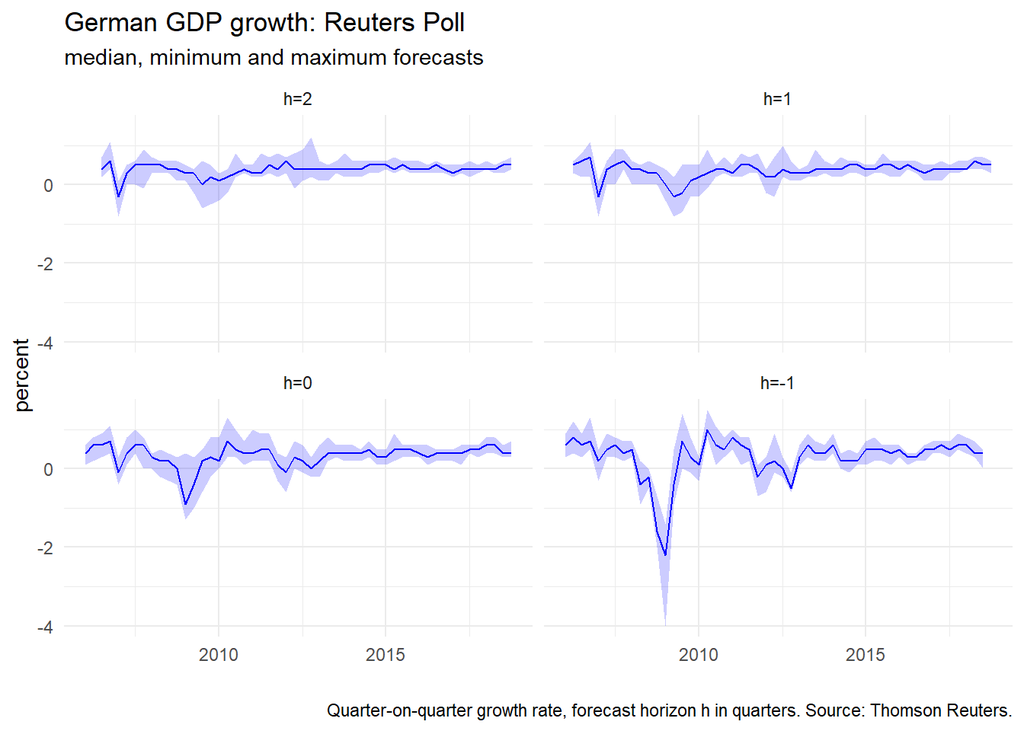

```r
ggplot(df, aes(x = quarter))+
  geom_ribbon(aes(ymin = min, ymax = max), fill = "blue", alpha = 0.2)+
  geom_line(aes(y = med), color = "blue")+
  facet_wrap( ~ fct_rev(horizon), nrow = 2)+
  labs(x = "", y = "percent",
       title = "German GDP growth: Reuters Poll",
       subtitle = "median, minimum and maximum forecasts",
       caption = "Quarter-on-quarter growth rate, forecast horizon h in quarters. Source: Thomson Reuters."
       )+
  theme_minimal()
```

## GDP

Source: [Deutsche Bundesbank, Real-time Database](https://www.bundesbank.de/dynamic/action/en/statistics/time-series-databases/time-series-databases/745590/real-time-data?statisticType=BBK_RTD&treeId=113205500)

```r
series <- "BBKRT.Q.DE.Y.A.AG1.CA010.A.I" # calendar and seasonally adjusted GDP
df_buba <- getSeries("BBKRT.Q.DE.Y.A.AG1.CA010.A.I")
```

function to calculate first release of quarterly GDP growth for a given vintage

```r
calc_first_release <- function(yy, qq, df)
{
  vintage_dates <- ymd(colnames(df_buba))
  ind_vintage <- sum(vintage_dates <= make_date(year = yy,
                                                month = 3 * qq,
                                                day= 1L)
                     ) + 1

  gdp <- df[, ind_vintage]

  ind_obs <- sum(!is.na(gdp))

  out <- gdp[ind_obs] / gdp[ind_obs - 1] * 100 - 100

  return(out)
}
```

loop over years and quarters

```r
df_releases <- data.frame()
for (yy in yys)
{
  for (qq in qqs)
  {
      actual <- calc_first_release(yy, qq, df_buba)
      df_releases <- rbind(df_releases,
                           data.frame(quarter = make_date(year = yy,
                                                          month = 3 * qq - 2,
                                                          day = 1),
                                      actual = actual)
                           )
  }
}
```

Merge with forecasts and tidy up

```r
df <- merge(df, df_releases, by = "quarter")
rm("df_buba", "df_releases")
```

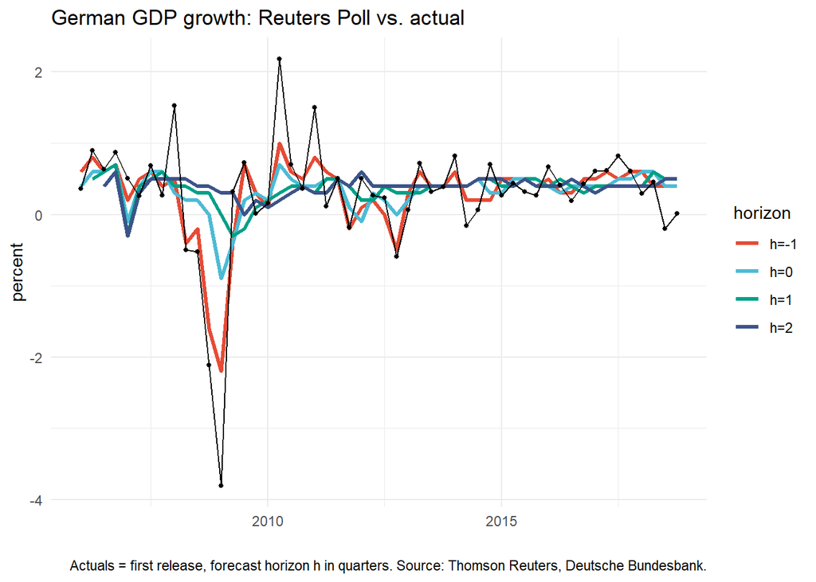

```r
ggplot(df, aes(x = quarter))+
  geom_line(aes(y = med, color = horizon), size = 1.1)+
  geom_line(aes(y = actual), color = "black")+
  geom_point(aes(y = actual), size = 1)+
  scale_color_npg()+
  labs(x = "", y = "percent",
       title = "German GDP growth: Reuters Poll vs. actual",
       caption = "Actuals = first release, forecast horizon h in quarters. Source: Thomson Reuters, Deutsche Bundesbank."
       )+
  theme_minimal()
```

## Analysis

Calculate forecast error `e`

```r
df$e <- df$med - df$actual
```

### Optimality of forecasts

The properties of optimal forecasts are ([Diebold and Lopez, 1995](https://www.nber.org/papers/t0192)):

- forecast errors with mean $0$
- at most $h-1$ serial correlation in $e$ for $h$-step ahead forecasts
- variance of forecast errors should be non-decreasing in the horizon

```r
tapply(df$e, df$horizon, mean, na.rm = T)
```

```
##         h=-1          h=0          h=1          h=2
## -0.004377685  0.047296434  0.071073805  0.105107611
```

On the whole, the forecasts are unbiased!

```r
#tapply(df$e, df$horizon, function(x){round(sqrt(mean(x^2, na.rm = T)), digits = 2)})
tapply(df$e, df$horizon, var, na.rm = T)
```

```
##      h=-1       h=0       h=1       h=2
## 0.1701583 0.4544355 0.6750575 0.7227619
```

Variance of the forecast errors is non-decreasing in the horizons

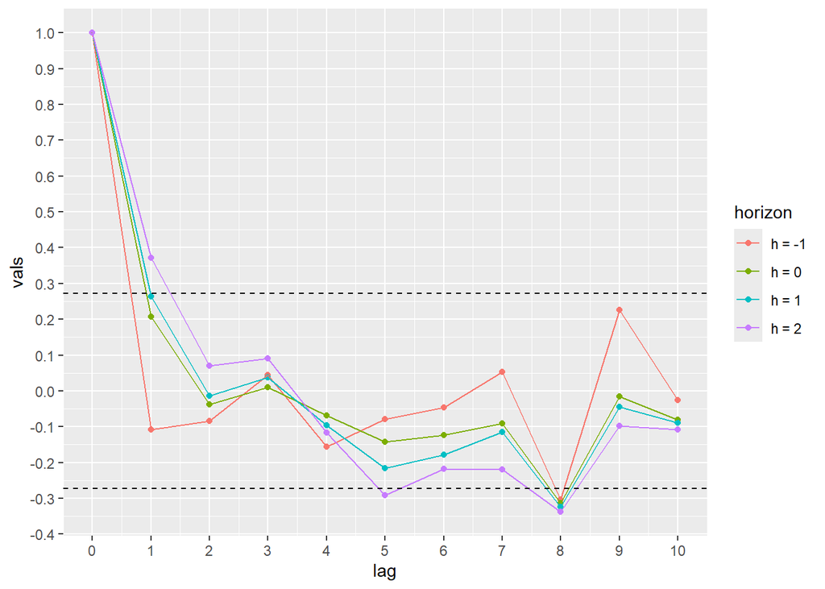

```r
Lmax <- 10 # maximum number of lags in ACF
tmp <- tapply(df$e, df$horizon, acf, na.action = na.pass, lag.max = Lmax, plot = F)
df_acf <- data.frame(lag = rep(tmp[[1]]$lag, times = length(tmp)),
                     horizon = rep(paste0("h = ", seq(-1,2)), each = Lmax + 1),
                     vals = c(tmp[[1]]$acf, tmp[[2]]$acf, tmp[[3]]$acf, tmp[[4]]$acf)
                    )

# plot acf function by horizon
ci <- 0.95 # confidence level
Nobs <- nrow(df) / length(unique(df$horizon)) # ignoring NA obs which are not used to calculate ACF
ggplot(df_acf, aes(x = lag, y = vals, group = horizon, color = horizon))+
  geom_point()+
  geom_line()+
  scale_x_continuous(breaks = seq(0, Lmax, by = 1))+
  scale_y_continuous(breaks = seq(1, min(df_acf$vals)-0.2, by = -0.1))+
  geom_hline(yintercept = qnorm((1 + ci)/2)/sqrt(52), size = 0.5, linetype = "dashed")+
  geom_hline(yintercept = -qnorm((1 + ci)/2)/sqrt(52), size = 0.5, linetype = "dashed")
```

For $h>-1$ the forecast errors exhibit some first-order serial correlation.

### Mincer-Zarnowitz regressions

$$y_{t+h} = \alpha + \beta f_{t+h|t} +
u_{t+h}, \forall \, t = 1, \dots T$$

The Mincer-Zarnowitz regressions test, whether forecasts are rational. Formally,

$$H_0: \alpha = 0, \beta = 1$$

versus the alternative $H_1: not \, H_0$

```r
library(car)
library(sandwich)
df_mz <- data.frame()
for (h_star in levels(df$horizon))
{
  tmp_model <- lm(actual ~ med, data = df, subset = df$horizon == h_star)

  rss_unrestr <- sum(residuals(tmp_model) ^ 2)
  rss_restr <- sum((tmp_model$model$actual - tmp_model$model$med) ^ 2)
  q <- 2 # number of restrictions
  k <- 1 # number of regressors in unrestricted model
  n <- length(tmp_model$model$med) # this gives the length of the actual regressor used!

  test_stat <- (rss_restr - rss_unrestr) / q / (rss_unrestr / (n - k - 1))
  pval <- 1 - pf(test_stat, q, n - k - 1)


  # NW variance-covariance matrix
  #NW_VCOV <- NeweyWest(lm(actual ~ med, data = df, subset = df$horizon == h_star),
  #                    lag = floor(0.75 * n^(1/3)), prewhite = F,
  #                    adjust = T)
  NW_VCOV <- NeweyWest(lm(actual ~ med, data = df, subset = df$horizon == h_star),
                      prewhite = FALSE)

  # HAC SE
  test_stat_hac <- linearHypothesis(tmp_model, c("(Intercept) = 0", "med = 1"), vcov.=NW_VCOV)[2,3]
  pval_hac <- linearHypothesis(tmp_model, c("(Intercept) = 0", "med = 1"), vcov.=NW_VCOV)[2,4]

  # heteroskedasticity-robust F-test
  #test_stat_het <- linearHypothesis(tmp_model, c("(Intercept) = 0", "med = 1"), white.adjust = "hc1")[2,3]
  #pval_het <- linearHypothesis(tmp_model, c("(Intercept) = 0", "med = 1"), white.adjust = "hc1")[2,4]


  df_tmp <- data.frame(horizon = h_star,
                       alpha = round(coefficients(tmp_model)[1], digits = 2),
                       beta = round(coefficients(tmp_model)[2], digits = 2),
                       R2 = round(summary(tmp_model)$r.squared, digits = 2),
                       n = n,
                       Fval_hac = round(test_stat_hac, digits = 2),
                       pval_hac = round(pval_hac, digits = 2)
                      )
  rownames(df_tmp) <- NULL
  df_mz <- rbind(df_mz, df_tmp)
}
```

```r
df_mz
```

| horizon | alpha | beta | R2 | n | Fval_hac | pval_hac |
| --- | --- | --- | --- | --- | --- | --- |
| h=-1 | -0.11 | 1.39 | 0.82 | 51 | 15.08 | 0.00 |
| h=0 | -0.40 | 2.05 | 0.46 | 52 | 1.77 | 0.18 |
| h=1 | -0.01 | 0.82 | 0.04 | 51 | 0.69 | 0.51 |
| h=2 | 0.35 | -0.18 | 0.00 | 51 | 6.97 | 0.00 |

There is clear evidence against forecast rationality for the backcasts and 2-step ahead forecasts while this is not the case for nowcasts and 1-step ahead forecasts.

## Sentiment

Load sentiment data, convert `quarter` to date format and standardize values!

```r
df_sentiment <- read.csv(paste0(getwd(), dir_sentiment, fname_sentiment),
                         stringsAsFactors = F)

df_sentiment$quarter <- as_date(df_sentiment$quarter)
df_sentiment$sentiment <- scale(df_sentiment$sentiment)
```

Merge with `df`

```r
df <- merge(df, df_sentiment, by = "quarter")
rm("df_sentiment")
```

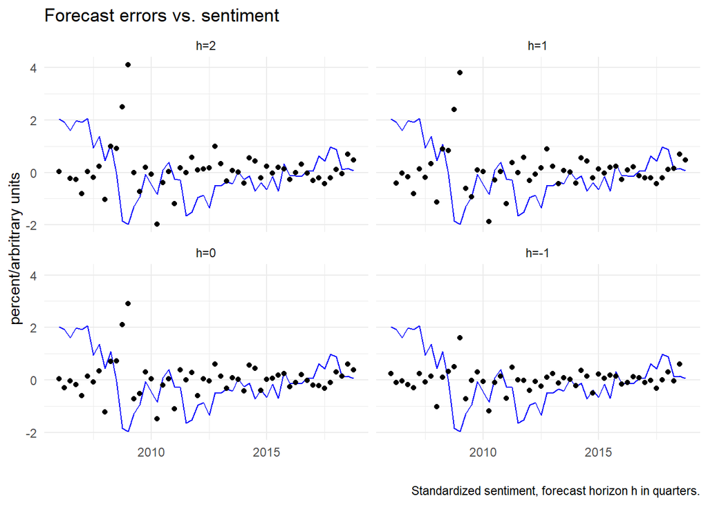

```r
ggplot(df, aes(x = quarter))+
  geom_line(aes(y = sentiment), color = "blue")+
  geom_point(aes(y = e))+
  facet_wrap( ~ fct_rev(horizon), nrow = 2)+
  labs(x = "", y = "percent/arbritrary units",
       title = "Forecast errors vs. sentiment",
       caption = "Standardized sentiment, forecast horizon h in quarters.")+
  theme_minimal()
```

Plot sentiment against GDP growth.

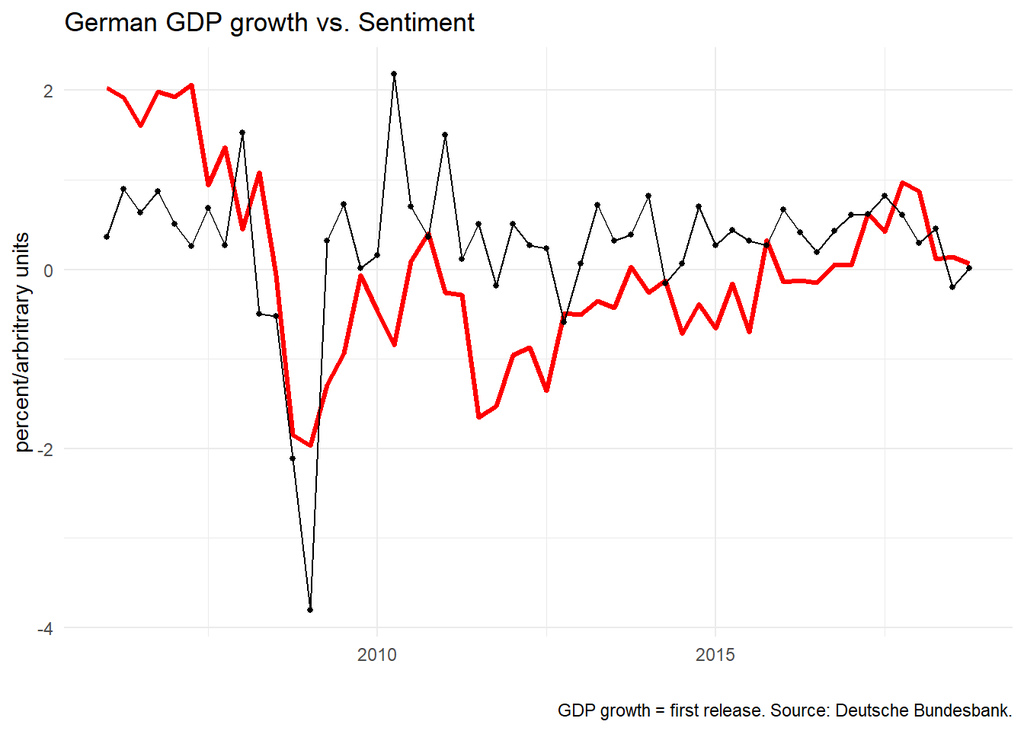

```r
ggplot(df, aes(x = quarter))+
  geom_line(aes(y = sentiment), color = "red", size = 1.1)+
  geom_line(aes(y = actual), color = "black")+
  geom_point(aes(y = actual), size = 1)+
  labs(x = "", y = "percent/arbritrary units",
       title = "German GDP growth vs. Sentiment",
       caption = "GDP growth = first release. Source: Deutsche Bundesbank."
       )+
  theme_minimal()
```

Calculate correlation between GDP growth and sentiment.

```r
cor(df$actual, df$sentiment)
```

```
##          [,1]
## [1,] 0.354079
```

### Augmented Mincer-Zarnowitz regression

$$y_{t+h} = \alpha + \beta f_{t+h|t} +
\gamma s_t + u_{t+h}, \forall \, t = 1, \dots T$$
In this regression: - $y_{t+h}$ is the actual GDP growth at time $t+h$, - $f_{t+h|t}$ is the professional forecast made at time $t$ (e.g., from Reuters), - $s_t$ is the sentiment, calculated based on information available up to $t$.

In this formulation, we test **forecast efficiency** with the null hypothesis

$$H_0: \alpha = 0, \beta = 1, \gamma =
0$$
.

The **encompassing test** checks whether

$$\gamma = 0$$
,

testing whether sentiment adds any new information beyond the professional forecast.

**Equivalent regression**: Regressing forecast error on forecast and sentiment

The above regression is equivalent to regressing the **forecast error** on both the forecast and sentiment:

$$\text{error}_{t+h} = \alpha + \beta
f_{t+h|t} + \gamma s_t + u_{t+h}$$
.

In this form: - **Forecast efficiency** is tested via the null hypothesis $H_0: \alpha = 0, \beta = 0, \gamma = 0$, meaning neither the forecast nor sentiment systematically explains the forecast error. - The **encompassing test** is still conducted by testing $\gamma = 0$, determining whether sentiment adds additional information not captured by the forecast.

We adopt the second version, where we regress the forecast error on the forecast and sentiment, following the approach in [Rambacussing and Kwiatkowski (2020, IJoF)](https://www.sciencedirect.com/science/article/abs/pii/S0169207020300595).

```r
library(lmtest)
df_mz_sentiment <- data.frame()
for (h_star in levels(df$horizon))
{
  tmp_model <- lm(actual - med ~ med + sentiment, data = df, subset = df$horizon == h_star)

  rss_unrestr <- sum(residuals(tmp_model) ^ 2)
  rss_restr <- sum((tmp_model$model$`actual - med`) ^ 2)
  q <- 3 # number of restrictions
  k <- 2 # number of regressors in unrestricted model
  # only rows with non-missing values are included
  n <- nrow(subset(df, df$horizon == h_star & complete.cases(actual, med, sentiment)))

  # full forecast efficiency
  test_stat <- (rss_restr - rss_unrestr) / q / (rss_unrestr / (n - k - 1))
  pval <- 1 - pf(test_stat, q, n - k - 1)

  # NW variance-covariance matrix
  #NW_VCOV <- NeweyWest(lm(actual ~ med + sentiment, data = df, subset = df$horizon == h_star),
  #                    lag = floor(0.75 * n^(1/3)), prewhite = F,
  #                    adjust = T)
  NW_VCOV <- NeweyWest(lm(actual-med ~ med + sentiment, data = df, subset = df$horizon == h_star),
                       prewhite = FALSE)

  # HAC SE
  # full forecast efficiency
  test_stat_hac <- linearHypothesis(tmp_model, c("(Intercept) = 0", "med = 0", "sentiment = 0"), vcov.=NW_VCOV)[2,3]
  pval_hac <- linearHypothesis(tmp_model, c("(Intercept) = 0", "med = 0", "sentiment = 0"), vcov.=NW_VCOV)[2,4]

  # Coefficient on sentiment (gamma)
  tgamma <- summary(tmp_model)$coefficients[["sentiment", "t value"]]
  tgamma_hac <- coeftest(tmp_model, vcov = NW_VCOV)[["sentiment", "t value"]]
  pval_gamma_hac <- coeftest(tmp_model, vcov = NW_VCOV)[["sentiment", "Pr(>|t|)"]]

  # Intercept (alpha)
  talpha <- summary(tmp_model)$coefficients[["(Intercept)", "t value"]]
  talpha_hac <- coeftest(tmp_model, vcov = NW_VCOV)[["(Intercept)", "t value"]]
  pval_alpha_hac <- coeftest(tmp_model, vcov = NW_VCOV)[["(Intercept)", "Pr(>|t|)"]]

  # Coefficient on med (beta)
  tbeta <- summary(tmp_model)$coefficients[["med", "t value"]]
  tbeta_hac <- coeftest(tmp_model, vcov = NW_VCOV)[["med", "t value"]]
  pval_beta_hac <- coeftest(tmp_model, vcov = NW_VCOV)[["med", "Pr(>|t|)"]]

  df_tmp <- data.frame(horizon = h_star,
                   alpha = round(coefficients(tmp_model)[1], digits = 2),
                   talpha_hac = round(talpha_hac, digits = 2),
                   pval_alpha_hac = round(pval_alpha_hac, digits = 2),

                   beta = round(coefficients(tmp_model)[2], digits = 2),
                   tbeta_hac = round(tbeta_hac, digits = 2),
                   pval_beta_hac = round(pval_beta_hac, digits = 2),

                   gamma = round(coefficients(tmp_model)[3], digits = 2),
                   tgamma_hac = round(tgamma_hac, digits = 2),
                   pval_gamma_hac = round(pval_gamma_hac, digits = 2),

                   R2 = round(summary(tmp_model)$r.squared, digits = 2),
                   n = n,

                   Fval_hac = round(test_stat_hac, digits = 2),
                   pval_hac = round(pval_hac, digits = 2)
                  )

   rownames(df_tmp) <- NULL
   df_mz_sentiment <- rbind(df_mz_sentiment, df_tmp)
}
```

```r
df_mz_sentiment
```

| horizon | alpha | talpha_hac | pval_alpha_hac | beta | tbeta_hac | pval_beta_hac | gamma | tgamma_hac | pval_gamma_hac | R2 | n | Fval_hac | pval_hac |
| --- | --- | --- | --- | --- | --- | --- | --- | --- | --- | --- | --- | --- | --- |
| h=-1 | -0.13 | -3.18 | 0.00 | 0.46 | 4.97 | 0.00 | -0.08 | -1.80 | 0.08 | 0.30 | 51 | 15.31 | 0.00 |
| h=0 | -0.38 | -2.22 | 0.03 | 0.99 | 2.12 | 0.04 | 0.03 | 0.46 | 0.65 | 0.18 | 52 | 2.07 | 0.12 |
| h=1 | 0.15 | 0.81 | 0.42 | -0.60 | -2.15 | 0.04 | 0.29 | 1.73 | 0.09 | 0.11 | 51 | 3.33 | 0.03 |
| h=2 | 0.32 | 1.01 | 0.32 | -1.09 | -1.76 | 0.09 | 0.29 | 1.48 | 0.15 | 0.15 | 51 | 2.16 | 0.11 |

The statistically significant $\gamma$ coefficient indicates that the sentiment provides additional information that can be used to improve the point forecasts for backcasts, as well as for one-step-ahead forecasts. Furthermore, the joint hypothesis that all coefficients $\alpha$, $\beta$, and $\gamma$ are equal to zero is rejected only for the forecast horizons $h=-1$ and $h=1$. This suggests that the professional forecasts are inefficient for these horizons.

Finally, we repeat the analysis for selected sign-adjusted topics. Specifically, we plot forecast errors and GDP growth against each sign-adjusted topic, calculate the correlation between each topic and GDP growth, and conduct the encompassing test for each topic to determine if it can improve point forecasts. The results are compiled and saved in a LaTeX table.

```r
# Load required libraries
library(knitr)
library(kableExtra)

# Set directories
output_dir_1 <- "/plots/errors_vs_sentiment/"
output_dir_2 <- "/plots/gdp_vs_sentiment/"
output_csv <- "correlation_results.csv"  # CSV file to store correlation results
output_latex <- "encompassing_test.tex"  # File to store LaTeX table

# Define the list of sign-adjusted topic files
sentiment_files <- c("T11_quarter.csv", "T27_quarter.csv", "T52_quarter.csv", "T74_quarter.csv",
                     "T77_quarter.csv", "T81_quarter.csv", "T100_quarter.csv", "T127_quarter.csv",
                     "T131_quarter.csv", "T138_quarter.csv")

# Initialize storage for correlations and regression results
correlation_results <- data.frame()
regression_results <- data.frame()

# Loop over each file
for (fname_sentiment in sentiment_files) {

  # Remove any existing 'sentiment' column from 'df' to avoid duplication
  if ("sentiment" %in% colnames(df)) {
    df$sentiment <- NULL
  }

  # Load sentiment data and standardize
  df_sentiment <- read.csv(paste0(getwd(), dir_sentiment, fname_sentiment), stringsAsFactors = FALSE)
  df_sentiment$quarter <- as.Date(df_sentiment$quarter)
  df_sentiment$sentiment <- scale(df_sentiment$sentiment)

  # Merge with existing forecast dataframe 'df'
  df <- merge(df, df_sentiment, by = "quarter")

  # Plot 1: Forecast errors vs. sign-adjusted topic
  p1 <- ggplot(df, aes(x = quarter)) +
    geom_line(aes(y = sentiment), color = "blue") +
    geom_point(aes(y = e)) +
    facet_wrap(~ fct_rev(horizon), nrow = 2) +
    labs(x = "", y = "percent/arbritrary units",
         title = paste("Forecast errors vs. sign-adjusted topic for", gsub("_quarter.csv", "", fname_sentiment)),
         caption = "Standardized sign-adjusted topic, forecast horizon h in quarters.") +
    theme_minimal()
  # Save plot
  ggsave(filename = paste0(getwd(), output_dir_1, gsub("_quarter.csv", "", fname_sentiment), "_errors_vs_topic.png"), plot = p1)

  # Plot 2: GDP growth vs. sign-adjusted topic
  p2 <- ggplot(df, aes(x = quarter)) +
    geom_line(aes(y = sentiment), color = "red", size = 1.1) +
    geom_line(aes(y = actual), color = "black") +
    geom_point(aes(y = actual), size = 1) +
    labs(x = "", y = "percent/arbritrary units",
         title = paste("German GDP growth vs. Sign-adjusted topic for", gsub("_quarter.csv", "", fname_sentiment)),
         caption = "GDP growth = first release. Source: Deutsche Bundesbank.") +
    theme_minimal()
  # Save plot
  ggsave(filename = paste0(getwd(), output_dir_2, gsub("_quarter.csv", "", fname_sentiment), "_gdp_vs_topic.png"), plot = p2)

   # Calculate and store correlation between GDP growth and sign-adjusted topic
  corr_value <- cor(df$actual, df$sentiment, use = "complete.obs")
  correlation_results <- rbind(correlation_results, data.frame(Topic = gsub("_quarter.csv", "", fname_sentiment),   Correlation = round(corr_value, 2)))

  # Regression analysis: Loop over horizons
  df_mz_sentiment <- data.frame()
  for (h_star in levels(df$horizon)) {

    # Run regression
    tmp_model <- lm(actual - med ~ med + sentiment, data = df, subset = df$horizon == h_star)

    # Calculate Newey-West standard errors
    NW_VCOV <- NeweyWest(tmp_model, prewhite = FALSE)

    # Joint hypothesis test for efficiency
    test_stat_hac <- linearHypothesis(tmp_model, c("(Intercept) = 0", "med = 0", "sentiment = 0"), vcov. = NW_VCOV)[2, 3]
    pval_hac <- linearHypothesis(tmp_model, c("(Intercept) = 0", "med = 0", "sentiment = 0"), vcov. = NW_VCOV)[2, 4]

    # Extract coefficients
    alpha <- coefficients(tmp_model)[1]
    beta <- coefficients(tmp_model)[2]
    gamma <- coefficients(tmp_model)[3]

    # HAC SE
    talpha_hac <- coeftest(tmp_model, vcov = NW_VCOV)[["(Intercept)", "t value"]]
    pval_alpha_hac <- coeftest(tmp_model, vcov = NW_VCOV)[["(Intercept)", "Pr(>|t|)"]]

    tbeta_hac <- coeftest(tmp_model, vcov = NW_VCOV)[["med", "t value"]]
    pval_beta_hac <- coeftest(tmp_model, vcov = NW_VCOV)[["med", "Pr(>|t|)"]]

    tgamma_hac <- coeftest(tmp_model, vcov = NW_VCOV)[["sentiment", "t value"]]
    pval_gamma_hac <- coeftest(tmp_model, vcov = NW_VCOV)[["sentiment", "Pr(>|t|)"]]

    # Store results in a temporary data frame
    df_tmp <- data.frame(horizon = h_star,
                         alpha = round(alpha, digits = 2),
                         talpha_hac = round(talpha_hac, digits = 2),
                         pval_alpha_hac = pval_alpha_hac,
                         beta = round(beta, digits = 2),
                         tbeta_hac = round(tbeta_hac, digits = 2),
                         pval_beta_hac = pval_beta_hac,
                         gamma = round(gamma, digits = 2),
                         tgamma_hac = round(tgamma_hac, digits = 2),
                         pval_gamma_hac = pval_gamma_hac,
                         topic = gsub("_quarter.csv", "", fname_sentiment)
                         )
    df_mz_sentiment <- rbind(df_mz_sentiment, df_tmp)
  }

  # Add the results for this sign-adjusted topic to the overall results
  regression_results <- rbind(regression_results, df_mz_sentiment)

  # Remove the topic data to avoid merging issues in the next iteration
  rm("df_sentiment")
}

# Save correlation results to CSV
write.csv(correlation_results, file = output_csv, row.names = FALSE)

# Create the formatted table as a data frame
formatted_table <- regression_results %>%
  # Add significance stars to each coefficient
  mutate(Significance = ifelse(pval_alpha_hac < 0.01, "***", ifelse(pval_alpha_hac < 0.05, "**", ifelse(pval_alpha_hac < 0.1, "*", "")))) %>%
  mutate(Intercept = paste0(round(alpha, 2), Significance)) %>%
  mutate(Significance = ifelse(pval_beta_hac < 0.01, "***", ifelse(pval_beta_hac < 0.05, "**", ifelse(pval_beta_hac < 0.1, "*", "")))) %>%
  mutate(SPF = paste0(round(beta, 2), Significance)) %>%
  mutate(Significance = ifelse(pval_gamma_hac < 0.01, "***", ifelse(pval_gamma_hac < 0.05, "**", ifelse(pval_gamma_hac < 0.1, "*", "")))) %>%
  mutate(Topic = paste0(round(gamma, 2), Significance)) %>%

  # Gather coefficients into a single "Regressor" column
  pivot_longer(cols = c(Intercept, SPF, Topic), names_to = "Regressor", values_to = "Value") %>%

  # Create a unique label combining `horizon` and `Regressor`
  mutate(Horizon_Regressor = paste(horizon, Regressor, sep = "_")) %>%

  # Pivot to wide format using `topic` as the new columns
  select(Horizon_Regressor, topic, Value) %>%
  pivot_wider(names_from = topic, values_from = Value) %>%

  # Separate `Horizon_Regressor` back into `horizon` and `Regressor`
  separate(Horizon_Regressor, into = c("horizon", "Regressor"), sep = "_") %>%

  # Arrange by `horizon` and then `Regressor` in the desired order
  arrange(factor(horizon, levels = unique(horizon)), factor(Regressor, levels = c("Intercept", "SPF", "Topic")))

# Create the LaTeX table with grouping
latex_output <- formatted_table %>%
  kable(format = "latex", booktabs = TRUE, linesep = "\\addlinespace[0.3em]", escape = FALSE) %>%
  kable_styling(font_size = 8, latex_options = c("hold_position"))

# Save to LaTeX file
write(latex_output, file = output_latex)
```